# Supervised Learning - Tree-Based Models Skill

從資料與變數介紹、遺失值處理到樹模型監督式學習的完整流程

作者

李慧敏

發佈於

2026年11月6日

# 摘要

本報告說明 `tree-based-models` Claude Skill 的方法與流程、檔案用途、使用方式與協作過程。Skill 針對表格型資料的監督式學習流程如下：

1. **資料與變數介紹**：資料是什麼、要預測什麼、用哪些變數。
2. **判斷任務類型**：分類或迴歸。
3. **敘述性統計**：統計量、分佈圖、與目標的關係、相關性。
4. **遺失值檢查**：沒有遺失就跳過；有遺失才診斷機制。
5. **資料切分**：測試集保留到最後，訓練集做 5 折交叉驗證。
6. **遺失值處理**：只在有遺失時比較 7 種插補方法。
7. **模型訓練與比較**：Decision Tree、Random Forest、Gradient Boosting，各自以 GridSearchCV 調參。

流程由 `eda_pipeline.py` 執行，輸出 HTML 報告、Excel 統計表與圖檔。另附迴歸（房價）、分類（葡萄酒）示範資料各一筆。

# 1 Skill 總覽

Skill 將正確的分析順序寫成固定流程，讓每次分析都依同一套標準完成並產出報告。

## 1.1 為什麼選擇樹模型

機器學習依「資料有沒有答案（標籤 $y$）」分成監督式與非監督式學習。本 Skill 處理的是**有目標欄位**的表格資料，屬於監督式學習；再依目標型態分成分類與迴歸，兩者都可以用樹模型處理。

```
%%{init: {'flowchart': {'useMaxWidth': true}}}%%
flowchart TB
  ML[機器學習] --> SL[監督式學習<br/>有目標欄位 y]
  ML --> UL[非監督式學習<br/>無目標：分群、降維]
  SL --> CLF[分類<br/>預測類別]
  SL --> REG[迴歸<br/>預測數值]
  CLF --> M{模型家族}
  REG --> M
  M --> LIN[線性模型<br/>需線性假設、對離群值敏感]
  M --> DIST[KNN / SVM<br/>需標準化]
  M --> NN[神經網路<br/>適合影像、文字，需大量資料]
  M --> TREE[樹模型<br/>本 Skill 採用]
  style TREE fill:#d8f0dd,stroke:#2e7d32,stroke-width:2px
```

圖 1: 監督式學習的分支與選擇樹模型的原因。

表 1: 選擇樹模型的原因

| 選擇樹模型的原因 | 說明 |
| --- | --- |
| 適合表格資料 | 數值與類別特徵可混合使用，中小型資料就能訓練 |
| 不需要特徵標準化 | 只看數值的大小順序，偏態與尺度不同都不影響 |
| 能捕捉非線性與交互作用 | 不必事先假設變數與目標是線性關係 |
| 對離群值穩健 | 切點只依排序決定，極端值影響小 |
| 分類與迴歸通用 | 同一套方法換成 `*Classifier` / `*Regressor` 即可 |
| 可解釋性與準確度兼顧 | 淺層決策樹可轉成規則；Random Forest、Gradient Boosting 提升準確度 |

## 1.2 分析流程

```
%%{init: {
  'theme': 'default',
  'themeVariables': { 'fontSize': '18px' },
  'flowchart': { 'useMaxWidth': true, 'nodeSpacing': 20, 'rankSpacing': 25, 'padding': 8 }
}}%%
flowchart LR
  A[資料與<br/>變數介紹] --> B[判斷任務<br/>分類/迴歸] --> C[敘述性<br/>統計] --> D{遺失值<br/>檢查}
  D -- 無 --> E1[資料<br/>切分] --> I[模型訓練與比較<br/>DT / RF / GB<br/>+ GridSearchCV]
  D -- 有 --> F[遺失機制<br/>診斷] --> E2[資料<br/>切分] --> H[插補方法比較<br/>只用訓練集 CV] --> I
```

圖 2: Skill 分析流程。

| 步驟 | 做什麼 | 產出 |
| --- | --- | --- |
| 1. 資料與變數介紹 | 資料說明、預測目標、使用變數；ID 欄位自動排除 | 變數介紹表 |
| 2. 判斷任務類型 | 依目標欄位的型態與取值判斷分類／迴歸 | 判斷依據表、目標分佈圖 |
| 3. 敘述性統計 | 統計量、分佈、與目標的關係、相關性 | 統計表、直方圖／長條圖、箱形圖、相關熱圖 |
| 4. 遺失值檢查 | 有遺失才算行／列遺失比例並診斷機制 | 遺失矩陣、遺失比例圖、機制診斷表 |
| 5. 資料切分 | 25% 測試集 + 訓練集 5 折 CV；分類 stratify | 切分示意圖、各類別訓練／測試筆數 |
| 6. 插補比較 | 7 種方法以同一模型、同一組 CV 折比較 | 下游 CV 比較圖、遮罩還原 NRMSE |
| 7. 模型訓練與比較 | 三個樹模型各自 GridSearchCV，測試集評估一次 | 調參表、模型比較、混淆矩陣／殘差圖、置換重要度 |

# 2 採用的方法

## 2.1 資料與變數介紹

報告開頭說明資料來源與筆數、要預測的目標（分類列各類別筆數，迴歸列單位、平均與範圍），以及每個特徵的說明與單位。說明文字來自欄位說明檔；ID 欄位會自動排除。

## 2.2 判斷分類或迴歸

任務類型決定模型、評估指標與切分方式，所以最先確定：

```
目標是文字 / 布林？            ──► 分類
數值但只有 2 種值（0/1）？      ──► 二元分類
整數且 ≤ 10 種值？             ──► 多類別分類
其餘（小數、很多不同值）        ──► 迴歸
```

表 2: 不同任務類型對應的模型、指標與切分方式

|  | 二元分類 | 多類別分類 | 迴歸 |
| --- | --- | --- | --- |
| sklearn 模型 | `*Classifier` | `*Classifier` | `*Regressor` |
| 分裂準則 | Gini / Entropy | Gini / Entropy | 平方誤差 |
| 調參與選模型指標 | AUC | Accuracy | RMSE |
| 其他報告指標 | PR-AUC、F1、ROC | Macro-F1、混淆矩陣 | MAE、R²、MAPE |
| 切分 | `StratifiedKFold` | `StratifiedKFold` | `KFold` |

## 2.3 敘述性統計

- **數值欄位**：平均數、標準差、四分位數、IQR、偏態、峰態、變異係數、1.5×IQR 離群值數。
- **類別欄位**：類別數、眾數與佔比、各水準次數。
- **與目標的關係**：以效果量列出最強的幾個特徵並畫圖。
- **相關性**：Spearman 相關熱圖；|ρ| > 0.8 的特徵對會特別指出。

## 2.4 遺失值：先檢查，有才處理

**註釋程式碼**

```python
miss = X.isna().sum()
print(miss[miss > 0], "完整列比例:", X.notna().all(axis=1).mean())
```

沒有遺失時，報告寫明「無遺失，跳過」並直接建模；有遺失時依序：

1. **遺失比例**：行（欄位）遺失比例 = 該欄遺失筆數 ÷ 總筆數；列（資料筆）遺失比例看每筆缺幾個欄位，可知整列刪除會丟多少資料。
2. **機制診斷**（Rubin, 1976）：Little’s MCAR 檢定，並逐欄比較「遺失 vs 未遺失」兩組的其他變數，推測 MCAR、MAR（或 MNAR）。MNAR 無法單靠資料證明，需領域知識判斷。
3. **插補比較**（只用訓練集）：整列刪除、中位數、平均數、中位數＋遺失指標、KNN、MICE（貝氏迴歸）、MICE（ExtraTrees），以同一個 Gradient Boosting、同一組 5 折 CV 比較下游分數。

## 2.5 資料切分

```
全部資料 ──► 測試集 25%
         └─► 訓練集 75% ──► 5 折交叉驗證（插補法、參數、最佳模型）
```

**註釋程式碼**

```python
X_tr, X_te, y_tr, y_te = train_test_split(X, y, test_size=0.25, random_state=42,
                                          stratify=y if is_clf else None)
cv = StratifiedKFold(5, shuffle=True, random_state=42) if is_clf else KFold(5, shuffle=True, random_state=42)
```

插補與編碼都放進 Pipeline，每一折只用訓練折 fit，避免資料洩漏；測試集只在最後評估一次。

## 2.6 模型與調參

表 3: 三個樹模型的調參設定

| 模型 | GridSearchCV 搜尋的參數 | 固定參數 |
| --- | --- | --- |
| Decision Tree | `max_depth`、`min_samples_leaf` | criterion（gini / squared_error） |
| Random Forest | `max_features`、`min_samples_leaf` | n_estimators=300 |
| Gradient Boosting | `n_estimators`、`learning_rate`、`max_depth` | subsample=0.8 |

**註釋程式碼**

```python
pipe = Pipeline([("imp", SimpleImputer(strategy="median")),
                 ("m", GradientBoostingRegressor(subsample=0.8, random_state=42))])
grid = {"m__n_estimators": [200, 400], "m__learning_rate": [0.05, 0.1], "m__max_depth": [3, 4, 5]}
gs = GridSearchCV(pipe, grid, cv=cv, scoring="neg_root_mean_squared_error").fit(X_tr, y_tr)
print(gs.best_params_, -gs.best_score_)          # 最佳參數與 CV RMSE；測試集只評估一次
```

# 3 樹模型架構與對應程式

```
flowchart LR
  DT[Decision Tree<br/>單棵樹・可解釋・高變異數]
  DT -- 並行・降變異數 --> RF[Random Forest<br/>Bootstrap + 特徵抽樣<br/>多棵深樹平均／投票]
  DT -- 序列・降偏差 --> GB[Gradient Boosting<br/>多棵淺樹<br/>依序擬合負梯度]
```

圖 3: 三個樹模型的關係：Random Forest 並行降變異數，Gradient Boosting 序列降偏差。

表 4: 三個樹模型的架構比較

| 面向 | Decision Tree | Random Forest | Gradient Boosting |
| --- | --- | --- | --- |
| 訓練方式 | 單棵 | 多棵獨立、並行 | 多棵依序修正 |
| 單棵樹 | 深或淺 | 深 | 淺（深度 2–5） |
| 主要降低 | — | 變異數 | 偏差 |
| 過擬合來源 | 樹太深 | 低（加樹不會變差） | 樹太多、學習率太大 |
| 可解釋性 | 最高 | 低 | 低 |

## 3.1 Decision Tree

每個節點遍歷「特徵 × 切點」，貪婪地選出讓不純度下降最多的切分（Breiman et al., 1984）；葉節點輸出類別比例（分類）或平均（迴歸）。

$$\text{Gain} = \text{Impurity(parent)} - \left[\frac{n_L}{n}\,\text{Impurity(left)} + \frac{n_R}{n}\,\text{Impurity(right)}\right], \qquad
\text{Gini} = 1 - \sum_k p_k^2$$

**註釋程式碼**

```python
from sklearn.tree import DecisionTreeClassifier, export_text

tree = DecisionTreeClassifier(max_depth=3, random_state=42).fit(X_train, y_train)
print(export_text(tree, feature_names=list(X_train.columns)))
```

## 3.2 Random Forest

以 bootstrap（取後放回抽樣）訓練多棵深樹，且每次分裂只從隨機抽出的 `max_features` 個特徵找切點，最後平均或投票（Breiman, 2001）。$B$ 棵樹、單棵變異數 $\sigma^2$、樹之間相關 $\rho$ 時：

$$\operatorname{Var}(\text{平均}) = \rho\,\sigma^2 + \frac{(1-\rho)\,\sigma^2}{B}$$

增加樹只能消掉第二項，特徵抽樣降低 $\rho$ 才能進一步降變異數。

特徵重要度方面，impurity 重要度偏好連續或高基數特徵，對純雜訊也會給分（Strobl et al., 2007），因此改用測試集上的**置換重要度**：打亂某欄後看指標掉多少。

**註釋程式碼**

```python
from sklearn.ensemble import RandomForestClassifier
from sklearn.inspection import permutation_importance

rf = RandomForestClassifier(n_estimators=300, max_features="sqrt", oob_score=True,
                            n_jobs=-1, random_state=42).fit(X_train, y_train)
print("OOB acc:", rf.oob_score_)
perm = permutation_importance(rf, X_test, y_test, n_repeats=20, random_state=42)
```

## 3.3 Gradient Boosting

加法模型，每一輪加入一棵淺樹 $h_m$ 擬合目前模型的負梯度，再以學習率 $\eta$ 縮放（Friedman, 2001）：

$$F_m(x) = F_{m-1}(x) + \eta\, h_m(x), \qquad
r_i = -\left.\frac{\partial L\big(y_i, F(x_i)\big)}{\partial F(x_i)}\right|_{F = F_{m-1}}$$

- **左式（逐步累加）**：$F_{m-1}$ 為前 $m-1$ 棵樹累加的預測，第 $m$ 棵淺樹 $h_m$ 負責修正剩下的誤差；學習率 $\eta$（0–1）讓每次只修正一小步，避免一次修過頭。
- **右式（新樹要學什麼）**：$r_i$ 為損失 $L$ 對目前預測的負梯度，代表第 $i$ 筆樣本「往哪個方向、修正多少」能讓損失變小；新樹 $h_m$ 即以 $r_i$ 為目標來訓練。

表 5: Gradient Boosting 的損失與負梯度

| 任務 | 損失 $L$ | 負梯度 $r_i$ | 直覺 |
| --- | --- | --- | --- |
| 迴歸 | $\tfrac{1}{2}(y-F)^2$ | $y - F$ | 殘差：目前還差多少 |
| 二元分類 | log loss，$p = \sigma(F)$ | $y - p$ | 真實標籤（0/1）與預測機率的差距 |
| 多類別（K 類） | 多項 log loss | $y_k - p_k$ | 每輪建 K 棵樹，第 $k$ 棵修正第 $k$ 類的機率 |

與 Random Forest 不同，**樹太多會過擬合**，所以 `n_estimators` 要和 `learning_rate` 一起調。

**註釋程式碼**

```python
from sklearn.ensemble import GradientBoostingClassifier

gb = GradientBoostingClassifier(n_estimators=2000, learning_rate=0.03, max_depth=2, subsample=0.8,
                                validation_fraction=0.2, n_iter_no_change=50, random_state=42)
gb.fit(X_train_imputed, y_train)
print("實際樹數:", gb.n_estimators_)
```

# 4 檔案說明

```
tree-based-models/
├── SKILL.md                          # Skill 主說明（Claude 讀取的入口）
├── scripts/
│   ├── eda_pipeline.py               # 主程式：完整流程 + 報表輸出
│   ├── demo_tree_models.py           # 教學用：樹模型行為 demo
│   └── make_demo_data.py             # 產生兩筆 demo 資料與欄位說明檔
├── references/
│   ├── eda-missing-data-guide.md     # 建模前流程教學 + demo 完整結果
│   ├── tree-based-models-guide.md    # 三個樹模型的原理與實務
│   └── *.txt                         # 腳本實際執行的輸出紀錄（核對數字用）
├── assets/                           # 兩筆 demo 資料與欄位說明檔
├── eda_regression_house_price/       # 房價 demo 的分析輸出
└── eda_classification_wine/          # 葡萄酒 demo 的分析輸出
```

表 6: 兩筆示範資料

|  | 迴歸：`regression_house_price.csv` | 分類：`classification_wine.csv` |
| --- | --- | --- |
| 要預測什麼 | 成交總價 `price_wan`（萬元） | 葡萄品種 `cultivar`（3 類，59 / 71 / 48） |
| 筆數／特徵 | 2,500 筆；10 個數值特徵 | 178 筆；13 個數值特徵（化學成分） |
| 遺失值 | 有 | 無 |
| 來源 | 模擬資料（`make_demo_data.py`，seed = 11） | UCI Wine（Aeberhard & Forina, 1992），取自 scikit-learn |

# 5 使用這個 Skill 的步驟

## 5.1 安裝與對話使用

將 `tree-based-models/` 資料夾放進 Claude 的 skills 目錄（或在 Skill 設定中上傳 zip）。之後在對話中提到 EDA、遺失值處理、決策樹／隨機森林／梯度提升等需求時，Claude 會讀取 `SKILL.md` 並依流程進行。

表 7: 常見的使用方式

| 你可以這樣說 | Claude 會做的事 |
| --- | --- |
| 「這個欄位有很多遺失，要怎麼補？」 | 依機制診斷與插補比較給建議 |
| 「demo 一下這個 skill」 | 分別跑房價與葡萄酒，各自比較模型 |

## 5.2 自己執行

```bash
pip install scikit-learn pandas numpy scipy matplotlib openpyxl

python scripts/eda_pipeline.py assets/regression_house_price.csv --target price_wan
python scripts/eda_pipeline.py assets/classification_wine.csv   --target cultivar
python scripts/eda_pipeline.py my_data.csv --target y --dict my_data_dictionary.csv
```

表 8: `eda_pipeline.py` 參數

| 參數 | 說明 |
| --- | --- |
| `--target` | 目標欄位（必填） |
| `--task` | `auto`（預設）/ `classification` / `regression` |
| `--dict` | 欄位說明檔；未指定時自動找 `<檔名>_dictionary.csv` |
| `--drop` / `--out` | 額外排除的欄位／輸出資料夾 |
| `--fast` / `--no-grid` | 跳過 MICE-ExtraTrees／不做 GridSearchCV（較快） |

輸出 `report.html`、`descriptive_stats.xlsx`、`figures/`、`report.txt`、`summary.json`；執行時間葡萄酒約 1 分鐘、房價約 2.5 分鐘。

# 6 示範結果

**迴歸：房價（有遺失）**

**執行程式**：在 `tree-based-models/` 資料夾下，一行指令跑完整流程，結果輸出到 `eda_regression_house_price/`：

```bash
python scripts/eda_pipeline.py assets/regression_house_price.csv --target price_wan --out eda_regression_house_price
```

其中最佳模型（Gradient Boosting）的核心步驟如下，單獨執行可得到相同的最佳參數與測試結果：

**註釋程式碼**

```python
import pandas as pd
from sklearn.model_selection import train_test_split, KFold, GridSearchCV
from sklearn.pipeline import Pipeline
from sklearn.impute import SimpleImputer
from sklearn.ensemble import GradientBoostingRegressor
from sklearn.metrics import root_mean_squared_error, r2_score

df = pd.read_csv("assets/regression_house_price.csv")
# 排除 ID 與目標
X, y = df.drop(columns=["listing_id", "price_wan"]), df["price_wan"]
X_tr, X_te, y_tr, y_te = train_test_split(X, y, test_size=0.25, random_state=42)
cv = KFold(5, shuffle=True, random_state=42)

# 插補比較後選中位數
pipe = Pipeline([("imp", SimpleImputer(strategy="median")),
                 ("m", GradientBoostingRegressor(subsample=0.8, random_state=42))])
grid = {"m__n_estimators": [200, 400], "m__learning_rate": [0.05, 0.1], "m__max_depth": [3, 4, 5]}
gs = GridSearchCV(pipe, grid, cv=cv, scoring="neg_root_mean_squared_error").fit(X_tr, y_tr)

# 測試集只評估一次
pred = gs.predict(X_te)
# CV RMSE ≈ 195
print(gs.best_params_, -gs.best_score_)
# 測試 RMSE ≈ 191、R² ≈ 0.89
print(root_mean_squared_error(y_te, pred), r2_score(y_te, pred))
```

**任務判斷**：`price_wan` 有 1,394 種不同數值 → 迴歸。

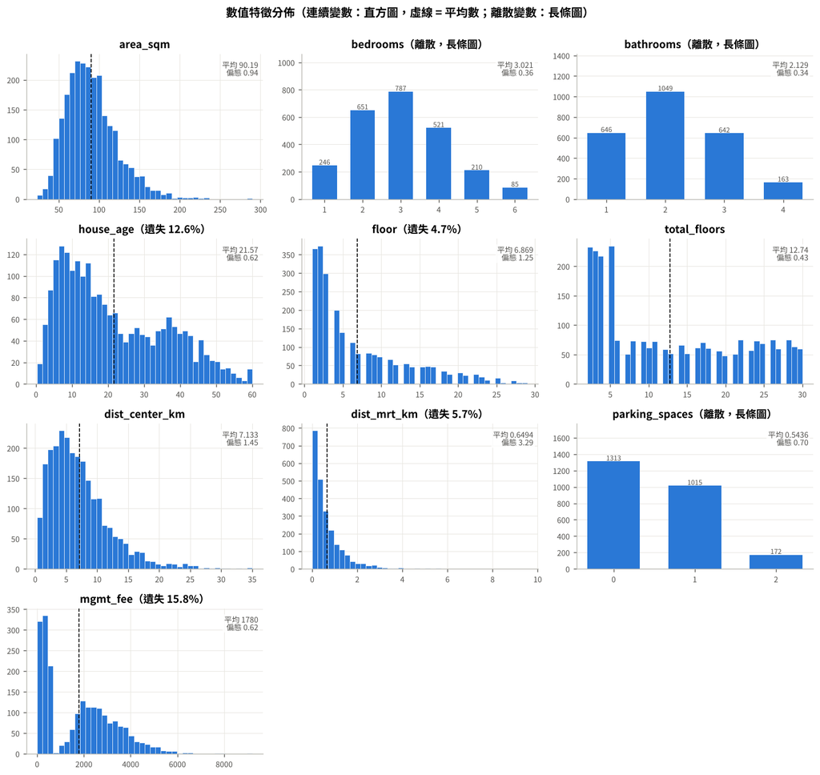

圖 4: 房價特徵分佈：連續變數為直方圖（虛線為平均數），房間數、衛浴數、車位數為長條圖

**遺失值**：4 個欄位遺失（管理費 15.8%、屋齡 12.6%、捷運距離 5.7%、樓層 4.7%），整列刪除會丟掉 35.1% 的資料；Little 檢定 p ≈ 9e-91，拒絕 MCAR。

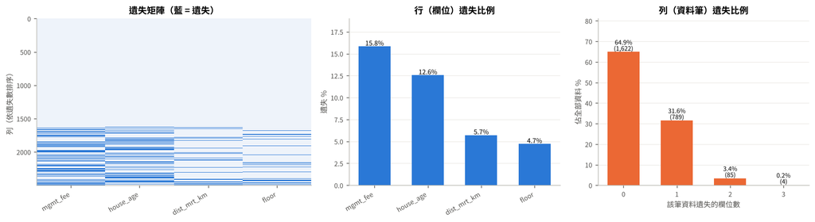

圖 5: 遺失矩陣、行（欄位）遺失比例、列（資料筆）遺失比例

**插補比較**（5 折 CV RMSE）：整列刪除 227.1 明顯最差；其餘方法介於 197.6–201.4，差距都在 1 個標準誤（約 3.9）內，所以選最簡單的**中位數**。

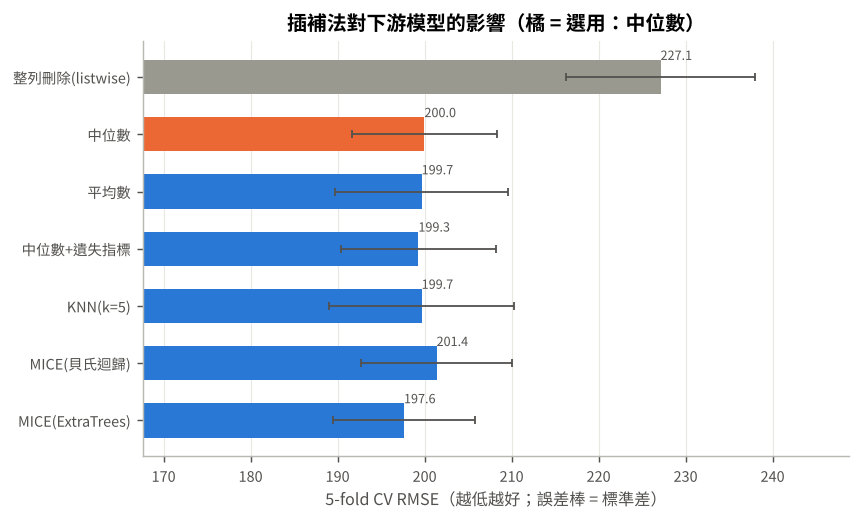

圖 6: 插補方法對下游模型的影響（橘色為選用）

表 9: 房價資料的模型比較（單位：萬元）

| 模型 | 最佳參數 | CV RMSE | 測試 RMSE | 測試 R² | 測試 MAPE |
| --- | --- | --- | --- | --- | --- |
| Decision Tree | max_depth=12、min_samples_leaf=10 | 276 | 274 | 0.78 | 18.1% |
| Random Forest | max_features=1.0、min_samples_leaf=1 | 217 | 217 | 0.86 | 14.4% |
| Gradient Boosting | n_estimators=400、learning_rate=0.05、max_depth=3 | **195** | **191** | **0.89** | **12.0%** |

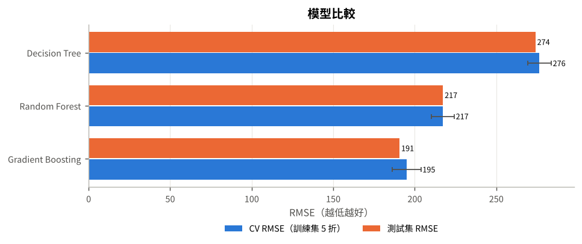

圖 7: 模型比較：藍為 CV RMSE（誤差棒為標準差），橘為測試 RMSE

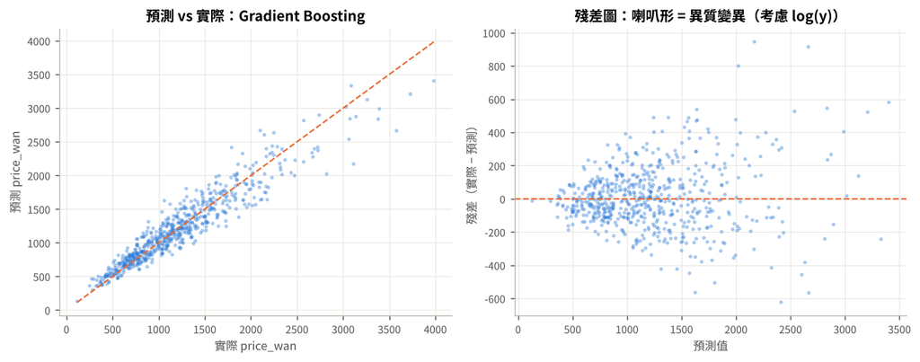

圖 8: 最佳模型（Gradient Boosting）的預測 vs 實際與殘差圖

**分類：葡萄酒（無遺失）**

**執行程式**：在 `tree-based-models/` 資料夾下，一行指令跑完整流程，結果輸出到 `eda_classification_wine/`：

```bash
python scripts/eda_pipeline.py assets/classification_wine.csv --target cultivar --out eda_classification_wine
```

其中最佳模型（Random Forest）的核心步驟如下，單獨執行可得到相同的最佳參數與測試結果：

**註釋程式碼**

```python
import pandas as pd
from sklearn.model_selection import train_test_split, StratifiedKFold, GridSearchCV
from sklearn.ensemble import RandomForestClassifier
from sklearn.metrics import accuracy_score, f1_score

df = pd.read_csv("assets/classification_wine.csv")
X, y = df.drop(columns=["cultivar"]), df["cultivar"]
X_tr, X_te, y_tr, y_te = train_test_split(X, y, test_size=0.25, stratify=y, random_state=42)
# 分類：各折保持類別比例
cv = StratifiedKFold(5, shuffle=True, random_state=42)

# 無遺失，不需插補
rf = RandomForestClassifier(n_estimators=300, n_jobs=-1, random_state=42)
grid = {"max_features": ["sqrt", 0.5, 1.0], "min_samples_leaf": [1, 3, 5]}
gs = GridSearchCV(rf, grid, cv=cv, scoring="accuracy").fit(X_tr, y_tr)

# 測試集只評估一次
pred = gs.predict(X_te)
# CV Accuracy ≈ 0.985
print(gs.best_params_, gs.best_score_)
# 測試 Accuracy = 1.000
print(accuracy_score(y_te, pred), f1_score(y_te, pred, average="macro"))
```

**任務判斷**：`cultivar` 是文字、3 種值 → 多類別分類。**遺失值**：13 個特徵 × 178 筆皆無遺失 → 跳過。

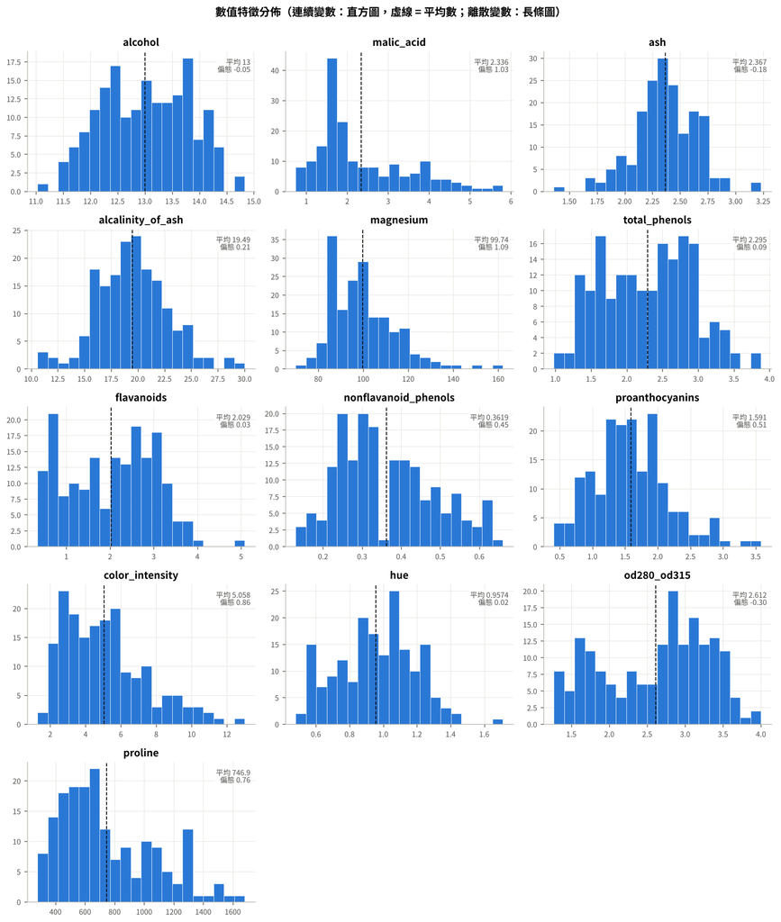

圖 9: 葡萄酒 13 個化學特徵的分佈（虛線為平均數）

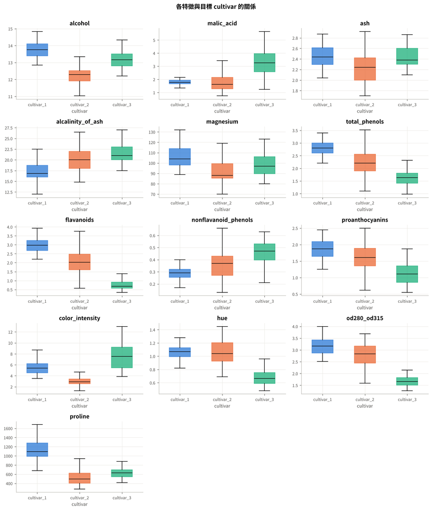

圖 10: 各特徵與品種的關係：類黃酮、脯胺酸、色澤強度最能區分品種

與品種關係最強的特徵為類黃酮 `flavanoids`（η² 0.73）、脯胺酸 `proline`（0.67）、色澤強度 `color_intensity`（0.65）；`total_phenols` 與 `flavanoids` 高度相關（ρ 0.88）。

**資料切分**：stratified 75/25，訓練 133 筆（44 / 53 / 36）、測試 45 筆（15 / 18 / 12）。

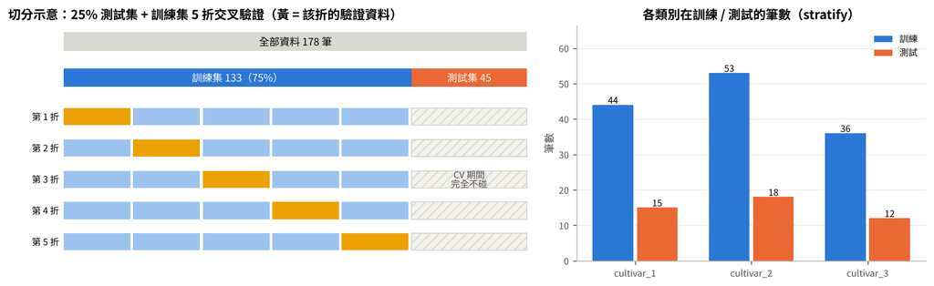

圖 11: 切分示意與各類別在訓練／測試的筆數

表 10: 葡萄酒的模型比較

| 模型 | 最佳參數 | CV Accuracy | 測試 Accuracy | 測試 Macro-F1 |
| --- | --- | --- | --- | --- |
| Decision Tree | max_depth=3、min_samples_leaf=1 | 0.910 | 0.956 | 0.957 |
| Random Forest | max_features=sqrt、min_samples_leaf=1 | **0.985** | **1.000** | **1.000** |
| Gradient Boosting | n_estimators=300、learning_rate=0.1、max_depth=2 | 0.978 | 0.978 | 0.980 |

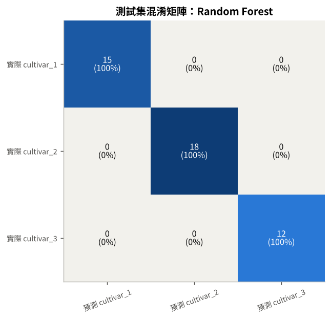

圖 12: 最佳模型（依 CV 為 Random Forest）的混淆矩陣：測試集 45 筆全部分類正確

單棵決策樹 CV 只有 0.910，兩個集成模型提升到 0.98 左右，集成的效果明顯。測試集只有 45 筆，猜錯 1 筆 Accuracy 就差 0.022，測試 1.000 不宜過度解讀，比較模型以 CV 為主。

## 6.1 兩筆結果的比較

表 11: 兩筆示範結果比較

|  | 迴歸：房價 | 分類：葡萄酒 |
| --- | --- | --- |
| 遺失值 | 有 → 診斷 + 插補（選中位數） | 無 → 跳過 |
| 切分 | 隨機 75/25 + KFold(5) | stratified 75/25 + StratifiedKFold(5) |
| 最佳模型 | Gradient Boosting（RMSE 191、R² 0.89） | Random Forest（CV 0.985、測試 1.000） |
| 解讀 | 集成模型明顯優於單棵樹 | 特徵多，集成模型明顯優於單棵樹（CV 0.98 vs 0.91） |

# 7 協作說明與 Skill 特點

## 7.1 協作說明

此 Skill 由 Claude 協作完成並逐步修正，主要方向：

1. **補上建模前流程**：加入分類與迴歸 demo 資料、EDA、遺失值診斷與插補，並輸出統計報表與圖。
2. **調整流程順序**：先介紹資料與變數再判斷任務類型；先檢查有無遺失，沒有就跳過；加入資料切分說明。
3. **讓報告更清楚**：說明預測目標與變數；離散變數用長條圖；遺失比例分行與列；交代各模型參數與調參方式。
4. **精簡模型與文件**：聚焦三個樹模型，所有文件附上參考資料與資料來源。

## 7.2 特點與限制

**特點**

- **固定且完整的流程**：自動完成並輸出報告，適用於任何表格型 CSV。
- **三個模型互補**：Decision Tree 可解釋；Random Forest 少調參就穩定；Gradient Boosting 調參後準確度通常最高。
- **評估方式正確**：插補與調參都在 Pipeline 內、只用訓練集 CV；測試集只評估一次。

**限制**

- 僅適用於上述三種樹模型，且只適合表格資料（影像、文字等應改用深度學習）。
- GridSearchCV 會窮舉參數組合，資料大或特徵多時耗時明顯增加。

# 參考資料

**方法與理論**

- Breiman, L., Friedman, J. H., Olshen, R. A., & Stone, C. J. (1984). *Classification and Regression Trees*. Wadsworth.
- Breiman, L. (1996). Bagging predictors. *Machine Learning*, 24(2), 123–140.
- Breiman, L. (2001). Random forests. *Machine Learning*, 45(1), 5–32.
- Friedman, J. H. (2001). Greedy function approximation: A gradient boosting machine. *The Annals of Statistics*, 29(5), 1189–1232.
- Friedman, J. H. (2002). Stochastic gradient boosting. *Computational Statistics & Data Analysis*, 38(4), 367–378.
- Hastie, T., Tibshirani, R., & Friedman, J. (2009). *The Elements of Statistical Learning* (2nd ed.). Springer.
- Rubin, D. B. (1976). Inference and missing data. *Biometrika*, 63(3), 581–592.
- Little, R. J. A. (1988). A test of missing completely at random for multivariate data with missing values. *Journal of the American Statistical Association*, 83(404), 1198–1202.
- Little, R. J. A., & Rubin, D. B. (2019). *Statistical Analysis with Missing Data* (3rd ed.). Wiley.
- van Buuren, S., & Groothuis-Oudshoorn, K. (2011). mice: Multivariate imputation by chained equations in R. *Journal of Statistical Software*, 45(3), 1–67.
- Troyanskaya, O., et al. (2001). Missing value estimation methods for DNA microarrays. *Bioinformatics*, 17(6), 520–525.
- Stekhoven, D. J., & Bühlmann, P. (2012). MissForest—non-parametric missing value imputation for mixed-type data. *Bioinformatics*, 28(1), 112–118.
- Strobl, C., Boulesteix, A.-L., Zeileis, A., & Hothorn, T. (2007). Bias in random forest variable importance measures. *BMC Bioinformatics*, 8, 25.
- Kohavi, R. (1995). A study of cross-validation and bootstrap for accuracy estimation and model selection. *Proceedings of IJCAI-95*, 1137–1143.
- Pedregosa, F., et al. (2011). Scikit-learn: Machine learning in Python. *Journal of Machine Learning Research*, 12, 2825–2830.

**資料來源**

- Aeberhard, S., & Forina, M. (1992). *Wine* [Dataset]. UCI Machine Learning Repository. https://doi.org/10.24432/C5PC7J（葡萄酒資料；取自 scikit-learn `load_wine()`）
- 房價資料：由 `scripts/make_demo_data.py` 以固定亂數種子（seed = 11）產生的模擬資料。